本文档代码主要来自于张旭阳，在此表示感谢。

- 关于效应量：ges和pes的区别
  - ges是generalized effect size，pes是partial effect size，二者的计算方式不同
  - 对于单样本独立测量ANOVA，两种eta值是一样的，报告哪个都无所谓；对于单样本重复测量ANOVA，按照课上讲的计算方式，我们应该报告pes而非ges。如果拿不准应该报告哪个效应量，建议都报告
  - **建议使用bruceR**，计算方法见hw7答案

$ges=\eta^2_G=\frac{SS_{effect}}{SS_{total}}$，$pes=\eta^2_p=\frac{SS_{effect}}{SS_{effect}+SS_{error}}$

## 1. 两因素混合设计方差分析（原理）

$$Y_{ijk}=\mu+\alpha_j+\beta_k+\pi_{i(j)}+(\alpha
\beta)_{jk}+(\pi \beta)_{ki(j)}+\epsilon_{ijk}$$

- 字母的含义：
  - $i$ 代表不同被试subject，$j$代表因素A（组间）的不同水平，$k$代表因素B（组内）的不同水平。
  - $\mu$代表总体均值
  - $\alpha_j$代表因素A的不同水平带来的影响，对应$SS_A$
  - $\beta_k$代表因素B的不同水平带来的影响，对应$SS_B$
  - $\pi_{i(j)}$代表A的不同水平下，被试之间的个体差异，$i$后面加了$j$，是因为一个被试只能属于$A_1,A_2,...,A_n$中的一个，属于随机误差项，对应$SS_{S/A}$。这里S指的是被试，A指的是因素A，S/A表示每个被试嵌套在条件A下。
  - $(\alpha \beta)_{jk}$代表因素A和因素B的交互作用，对应$SS_{A \times B}$
  - $(\pi \beta)_{ki(j)}+\epsilon_{ijk}$代表被试与因素B的交互作用和随机误差之和，对应$SS_{B\times S/A}$
    - 被试与因素B的交互作用：B的不同水平对不同被试的影响不同。例如，被试1在B1条件下的表现优于B2优于B3，而被试2在B1条件下的表现劣于B2劣于B3。
    - 但是，被试与因素B的交互作用$(\pi \beta)_{ki(j)}$和随机误差$\epsilon_{ijk}$区分不开。因为每个被试在B的每个水平下只有一个观测，无法计算出被试和B的交互作用的大小。
- 为什么计算F值时，使用了不同的MSE？
  - 可以粗略地理解为，计算$F_A$时，需要考虑【A的效应】VS【只与A有关的误差】之间的大小关系；计算$F_B$和$F_{A \times B}$时，需要考虑【B（或者A×B）的效应】VS【与B有关的误差】之间的大小关系。
  - 计算$F_A$时，分母是$MS_{S/A}$

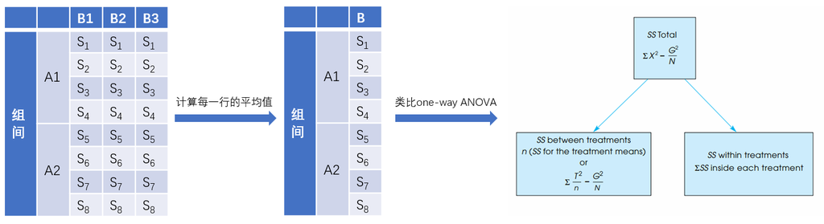

    - **每个被试**都在B的不同水平下完成了测验，B的影响可以在被试内平均掉，计算误差项时，只需要考虑【被试的实际表现】与【A1、A2均值】的差异。误差项是$SS_{S/A}$，即A的不同水平下，被试之间的个体差异之和。
    - $SS_A=\sum n_j (\bar{Y_{.j.}}-\bar{Y_{...}})^2,df_A=a-1$
    - $SS_{S/A}=k \sum (\bar{Y_{i..}}-\bar{Y_{.j.}})^2,df_{S/A}=a(s-1)$
  - 计算$F_B$和$F_{A \times B}$时，分母是$MS_{B*S/A}$
    - 每名被试只接受A的一个水平的处理，无法平均掉A的影响，计算误差项时，需要考虑【被试的实际表现】与【A和B不同组合的均值】的差异。误差项是$SS_{B \times S/A}$，即AB的不同组合下，被试之间的个体差异之和（即$\sum (\bar{Y_{ijk}}-\bar{Y_{.jk}})^2$），减去A的不同水平下被试之间的差异之和（即$SS_{S/A}=k \sum (\bar{Y_{i..}}-\bar{Y_{.j.}})^2$）。
    - $SS_B=\sum n_k (\bar{Y_{..k}}-\bar{Y_{...}})^2,df_B=b-1$
    - $SS_{A \times B}=\sum n_{jk} (\bar{Y_{.jk}}-\bar{Y_{...}})^2 - SS_A - SS_B,df_{A \times B}=(a-1)(b-1)$
    - $SS_{B\times S/A}=\sum (\bar{Y_{ijk}}-\bar{Y_{.jk}})^2- k \sum (\bar{Y_{i..}}-\bar{Y_{.j.}})^2,df_{B\times S/A}=ab(s-1)-df_{S/A}=ab(s-1)-a(s-1)=a(b-1)(s-1)$

## 2. 两因素混合设计方差分析（代码）

- (a)数据结构和描述性统计
- (b)MANOVA + EMMEANS + emmip
- (c)工整地报告结果

### (a)数据结构和描述性统计

```r
# 本研究的数据
library(tidyverse)
mix_data <- data.frame(
  subID = 1:15,
  Type = rep(c('Fiction','Mystery','Romance'),each=5),
  Month1 = c(1,1,3,5,2,3,4,5,4,4,4,2,3,6,3),
  Month2 = c(3,4,3,5,4,1,4,3,2,5,2,6,3,2,3),
  Month3 = c(6,8,6,7,5,0,2,2,0,3,0,1,3,1,2))

mix_data %>%
  select(Type, Month1, Month2,Month3) %>%
  group_by(Type) %>%
  summarise_all(mean)
```

```
## # A tibble: 3 × 4
##   Type    Month1 Month2 Month3
##   <chr>    <dbl>  <dbl>  <dbl>
## 1 Fiction    2.4    3.8    6.4
## 2 Mystery    4      3      1.4
## 3 Romance    3.6    3.2    1.4
```

```r
library(reshape2)
mix_long <- melt(mix_data, id=c('subID','Type'), # id是保持不变的列
                 variable.name = 'Month', # variable.name是自变量的名字
                 value.name = 'num') # value.name是因变量的名字

mix_long %>%
  group_by(Type,Month) %>%
  summarise(M = mean(num), se = sd(num)/sqrt(length(num)))
```

```
## # A tibble: 9 × 4
## # Groups:   Type [3]
##   Type    Month      M    se
##   <chr>   <fct>  <dbl> <dbl>
## 1 Fiction Month1   2.4 0.748
## 2 Fiction Month2   3.8 0.374
## 3 Fiction Month3   6.4 0.510
## 4 Mystery Month1   4   0.316
## 5 Mystery Month2   3   0.707
## 6 Mystery Month3   1.4 0.6
## 7 Romance Month1   3.6 0.678
## 8 Romance Month2   3.2 0.735
## 9 Romance Month3   1.4 0.510
```

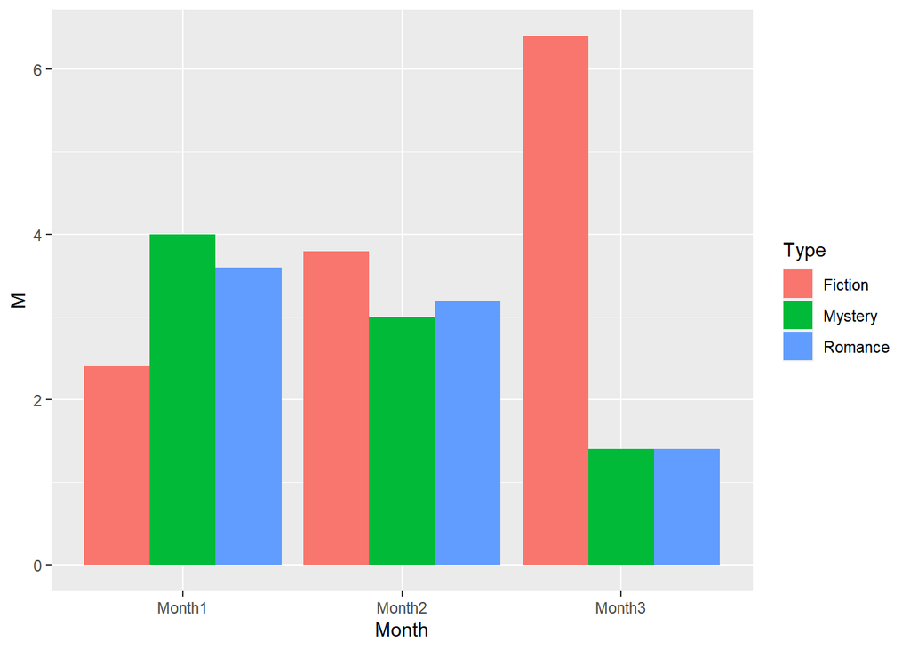

```r
mix_long %>%
  group_by(Type,Month) %>%
  summarise(M = mean(num), se = sd(num)/sqrt(length(num))) %>%
  ggplot(aes(Month, M, fill = Type)) +
  geom_bar(stat = 'identity', position = 'dodge')
```

### (b)MANOVA+EMMEANS+emmip

(1)前提检验：观测独立性，正态性Shapiro Test，方差同质性LeveneTest和协方差同质性Mauchly W  
(2)MANOVA函数：data, dv, between三个参数  
(3)主效应+事后检验  
(4)交互作用+简单主效应+事后检验  
(5)EMMEANS函数：model, effect, by三个参数

```r
# 手算SS，对照着图来看
SS <- function(x){return(var(x)*(length(x)-1))}

mix_long %>%
  group_by(Type) %>% mutate(Typemean = mean(num)) %>%
  group_by(Month) %>% mutate(Monthmean = mean(num)) %>%
  group_by(Month, Type) %>% mutate(Intermean = mean(num)) %>%
  group_by(Type, subID) %>% mutate(Submean1 = mean(num), Typeerror = Submean1-Typemean) %>%
  group_by(Type, Month, subID) %>% mutate(Submean2 = mean(num), error = Submean2-Intermean) %>%
  ungroup() %>%
  summarise(SS_Type = SS(Typemean), SS_Typeerror = SS(Typeerror),
            SS_Month = SS(Monthmean), SS_TM = SS(Intermean)-SS_Type-SS_Month,
            SS_error = SS(error)-SS_Typeerror)
```

```
## # A tibble: 1 × 5
##   SS_Type SS_Typeerror SS_Month SS_TM SS_error
##     <dbl>        <dbl>    <dbl> <dbl>    <dbl>
## 1    20.6         26.4    0.711  71.4     37.2
```

#### 正态性

每个格子的数据都要服从正态分布。例如，有组间条件A（A1、A2、A3）和组内条件B（B1、B2、B3），那么九个格子的数据都要服从正态分布。

```r
library(rstatix)
# check normality [宽数据]
mix_data %>%
  group_by(Type) %>%
  shapiro_test(Month1)
```

```
## # A tibble: 3 × 4
##   Type    variable statistic     p
##   <chr>   <chr>        <dbl> <dbl>
## 1 Fiction Month1       0.881 0.314
## 2 Mystery Month1       0.883 0.325
## 3 Romance Month1       0.914 0.492
```

```r
mix_data %>%
  group_by(Type) %>%
  shapiro_test(Month2)
```

```
## # A tibble: 3 × 4
##   Type    variable statistic      p
##   <chr>   <chr>        <dbl>  <dbl>
## 1 Fiction Month2       0.881 0.314
## 2 Mystery Month2       0.987 0.967
## 3 Romance Month2       0.779 0.0537
```

```r
mix_data %>%
  group_by(Type) %>%
  shapiro_test(Month3)
```

```
## # A tibble: 3 × 4
##   Type    variable statistic     p
##   <chr>   <chr>        <dbl> <dbl>
## 1 Fiction Month3       0.961 0.814
## 2 Mystery Month3       0.852 0.201
## 3 Romance Month3       0.961 0.814
```

```r
# check normality [长数据]
mix_long %>%
  group_by(Type, Month) %>%
  shapiro_test(num)
```

```
## # A tibble: 9 × 5
##   Type    Month  variable statistic      p
##   <chr>   <fct>  <chr>        <dbl>  <dbl>
## 1 Fiction Month1 num          0.881 0.314
## 2 Fiction Month2 num          0.881 0.314
## 3 Fiction Month3 num          0.961 0.814
## 4 Mystery Month1 num          0.883 0.325
## 5 Mystery Month2 num          0.987 0.967
## 6 Mystery Month3 num          0.852 0.201
## 7 Romance Month1 num          0.914 0.492
## 8 Romance Month2 num          0.779 0.0537
## 9 Romance Month3 num          0.961 0.814
```

#### 方差同质性

比较的是各处理组间的方差同质性。例如，有组间条件A（A1、A2、A3）和组内条件B（B1、B2、B3），那么：

- 对于组内条件B1而言，B1A1、B1A2、B1A3的方差同质
- 对于组内条件B2而言，B2A1、B2A2、B2A3的方差同质
- 对于组内条件B3而言，B3A1、B3A2、B3A3的方差同质

#### 球形性

比较的是各处理组内的协方差同质性

```r
library(bruceR)
# mixed Anova, Levene’s Test, Mauchly’s Test
m = mix_data %>% MANOVA(dvs = 'Month1:Month3', dvs.pattern='Month(.)',
                        between = 'Type', within = 'Month')
```

```
##
## Note:
## dvs="Month1:Month3" is matched to variables:
## Month1, Month2, Month3
```

```
##
## ====== ANOVA (Mixed Design) ======
##
## Descriptives:
## ────────────────────────────────
##   "Type" "Month"  Mean    S.D. n
## ────────────────────────────────
##  Fiction  Month1 2.400 (1.673) 5
##  Fiction  Month2 3.800 (0.837) 5
##  Fiction  Month3 6.400 (1.140) 5
##  Mystery  Month1 4.000 (0.707) 5
##  Mystery  Month2 3.000 (1.581) 5
##  Mystery  Month3 1.400 (1.342) 5
##  Romance  Month1 3.600 (1.517) 5
##  Romance  Month2 3.200 (1.643) 5
##  Romance  Month3 1.400 (1.140) 5
## ────────────────────────────────
## Total sample size: N = 15
##
## ANOVA Table:
## Dependent variable(s):      Month1, Month2, Month3
## Between-subjects factor(s): Type
## Within-subjects factor(s):  Month
## Covariate(s):               –
## ────────────────────────────────────────────────────────────────────────────
##                   MS   MSE df1 df2      F     p     η²p [90% CI of η²p]  η²G
## ────────────────────────────────────────────────────────────────────────────
## Type          10.289 2.200   2  12  4.677  .031 *     .438 [.034, .659] .244
## Month          0.356 1.550   2  24  0.229  .797       .019 [.000, .117] .011
## Type * Month  17.856 1.550   4  24 11.520 <.001 ***   .658 [.415, .766] .529
## ────────────────────────────────────────────────────────────────────────────
## MSE = mean square error (the residual variance of the linear model)
## η²p = partial eta-squared = SS / (SS + SSE) = F * df1 / (F * df1 + df2)
## ω²p = partial omega-squared = (F - 1) * df1 / (F * df1 + df2 + 1)
## η²G = generalized eta-squared (see Olejnik & Algina, 2003)
## Cohen’s f² = η²p / (1 - η²p)
##
## Levene’s Test for Homogeneity of Variance:
## ────────────────────────────────────────
##             Levene’s F df1 df2     p
## ────────────────────────────────────────
## DV: Month1       1.848   2  12  .200
## DV: Month2       0.681   2  12  .525
## DV: Month3       0.321   2  12  .731
## ────────────────────────────────────────
##
## Mauchly’s Test of Sphericity:
## ───────────────────────────────────
##               Mauchly's W     p
## ───────────────────────────────────
## Month              0.7890  .272
## Type * Month       0.7890  .272
## ───────────────────────────────────
```

```r
# m = mix_long %>% MANOVA(dv = 'num', between = 'Type', within = 'Month',
#                     subID = 'subID')
```

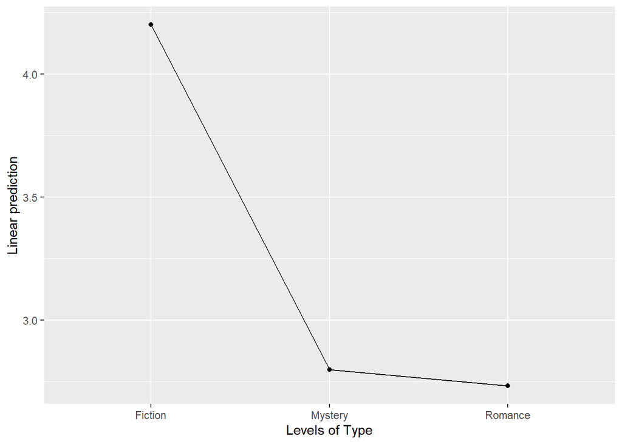

```r
# type主效应（month同理，但因为不显著，略）
m %>% emmip(~Type) # plot
```

```r
m %>% EMMEANS(effect = 'Type')
```

```
## ------ EMMEANS (effect = "Type") ------
##
## Joint Tests of "Type":
## ──────────────────────────────────────────────────────────
##        Effect df1 df2      F     p     η²p [90% CI of η²p]
## ──────────────────────────────────────────────────────────
##  Type           2  12  4.677  .031 *     .438 [.034, .659]
##  Month          2  12  0.394  .683       .062 [.000, .277]
##  Type * Month   4  12 16.061 <.001 ***   .843 [.627, .908]
## ──────────────────────────────────────────────────────────
## Note. Simple effects of repeated measures with 3 or more levels
## are different from the results obtained with SPSS MANOVA syntax.
##
## Estimated Marginal Means of "Type":
## ──────────────────────────────────────
##   "Type" Mean [95% CI of Mean]    S.E.
## ──────────────────────────────────────
##  Fiction  4.200 [3.366, 5.034] (0.383)
##  Mystery  2.800 [1.966, 3.634] (0.383)
##  Romance  2.733 [1.899, 3.568] (0.383)
## ──────────────────────────────────────
##
## Pairwise Comparisons of "Type":
## ───────────────────────────────────────────────────────────────────────────────
##           Contrast Estimate    S.E. df      t     p     Cohen’s d [95% CI of d]
## ───────────────────────────────────────────────────────────────────────────────
##  Mystery - Fiction   -1.400 (0.542) 12 -2.585  .072 .    -0.859 [-1.782, 0.065]
##  Romance - Fiction   -1.467 (0.542) 12 -2.708  .057 .    -0.900 [-1.823, 0.024]
##  Romance - Mystery   -0.067 (0.542) 12 -0.123 1.000      -0.041 [-0.964, 0.883]
## ───────────────────────────────────────────────────────────────────────────────
## Pooled SD for computing Cohen’s d: 1.630
## Results are averaged over the levels of: Month
## P-value adjustment: Bonferroni method for 3 tests.
##
## Disclaimer:
## By default, pooled SD is Root Mean Square Error (RMSE).
## There is much disagreement on how to compute Cohen’s d.
## You are completely responsible for setting `sd.pooled`.
## You might also use `effectsize::t_to_d()` to compute d.
```

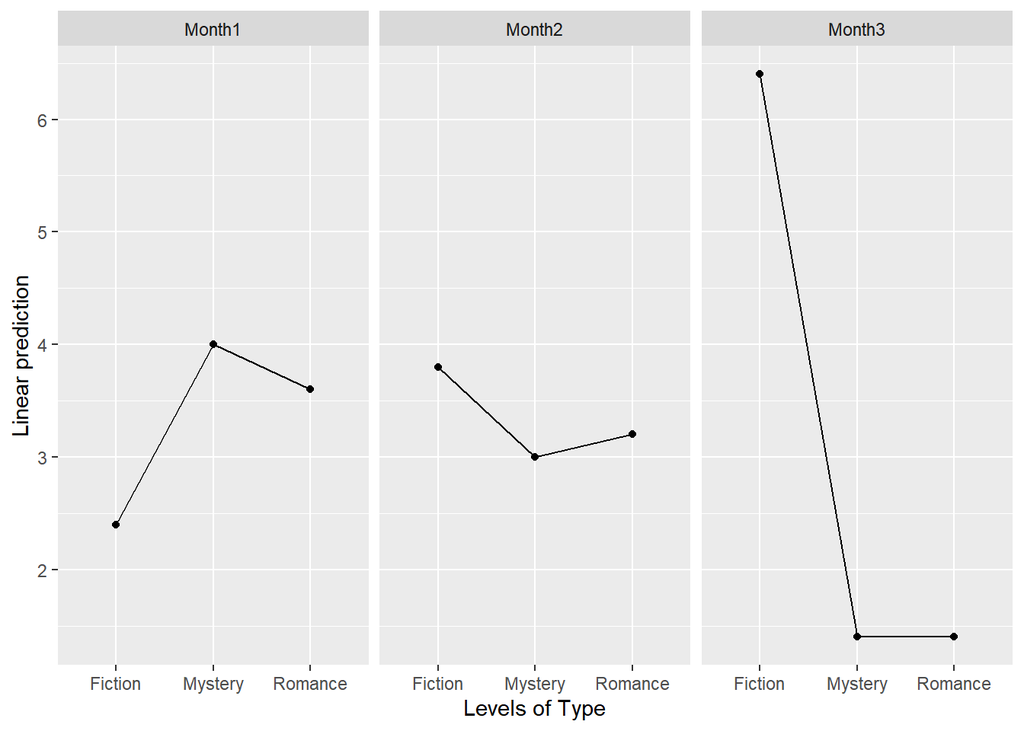

```r
#Type的简单主效应
m %>% emmip(~Type|Month)
```

```r
m %>% EMMEANS(effect = 'Type', by = 'Month')
```

```
## ------ EMMEANS (effect = "Type") ------
##
## Joint Tests of "Type":
## ────────────────────────────────────────────────────────────
##  Effect "Month" df1 df2      F     p     η²p [90% CI of η²p]
## ────────────────────────────────────────────────────────────
##    Type  Month1   2  12  1.857  .198       .236 [.000, .500]
##    Type  Month2   2  12  0.441  .654       .068 [.000, .291]
##    Type  Month3   2  12 28.409 <.001 ***   .826 [.612, .900]
## ────────────────────────────────────────────────────────────
## Note. Simple effects of repeated measures with 3 or more levels
## are different from the results obtained with SPSS MANOVA syntax.
##
## Estimated Marginal Means of "Type":
## ──────────────────────────────────────────────
##   "Type" "Month" Mean [95% CI of Mean]    S.E.
## ──────────────────────────────────────────────
##  Fiction  Month1  2.400 [1.069, 3.731] (0.611)
##  Mystery  Month1  4.000 [2.669, 5.331] (0.611)
##  Romance  Month1  3.600 [2.269, 4.931] (0.611)
##  Fiction  Month2  3.800 [2.434, 5.166] (0.627)
##  Mystery  Month2  3.000 [1.634, 4.366] (0.627)
##  Romance  Month2  3.200 [1.834, 4.566] (0.627)
##  Fiction  Month3  6.400 [5.220, 7.580] (0.542)
##  Mystery  Month3  1.400 [0.220, 2.580] (0.542)
##  Romance  Month3  1.400 [0.220, 2.580] (0.542)
## ──────────────────────────────────────────────
##
## Pairwise Comparisons of "Type":
## ───────────────────────────────────────────────────────────────────────────────────────
##           Contrast "Month" Estimate    S.E. df      t     p     Cohen’s d [95% CI of d]
## ───────────────────────────────────────────────────────────────────────────────────────
##  Mystery - Fiction  Month1    1.600 (0.864) 12  1.852  .266      0.982 [-0.492,  2.455]
##  Romance - Fiction  Month1    1.200 (0.864) 12  1.389  .570      0.736 [-0.737,  2.210]
##  Romance - Mystery  Month1   -0.400 (0.864) 12 -0.463 1.000     -0.245 [-1.719,  1.228]
##  Mystery - Fiction  Month2   -0.800 (0.887) 12 -0.902 1.000     -0.491 [-2.003,  1.022]
##  Romance - Fiction  Month2   -0.600 (0.887) 12 -0.676 1.000     -0.368 [-1.880,  1.144]
##  Romance - Mystery  Month2    0.200 (0.887) 12  0.225 1.000      0.123 [-1.390,  1.635]
##  Mystery - Fiction  Month3   -5.000 (0.766) 12 -6.528 <.001 *** -3.067 [-4.373, -1.761]
##  Romance - Fiction  Month3   -5.000 (0.766) 12 -6.528 <.001 *** -3.067 [-4.373, -1.761]
##  Romance - Mystery  Month3   -0.000 (0.766) 12 -0.000 1.000     -0.000 [-1.306,  1.306]
## ───────────────────────────────────────────────────────────────────────────────────────
## Pooled SD for computing Cohen’s d: 1.630
## P-value adjustment: Bonferroni method for 3 tests.
##
## Disclaimer:
## By default, pooled SD is Root Mean Square Error (RMSE).
## There is much disagreement on how to compute Cohen’s d.
## You are completely responsible for setting `sd.pooled`.
## You might also use `effectsize::t_to_d()` to compute d.
```

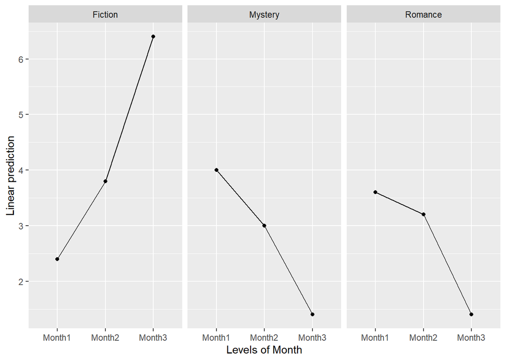

```r
#Month的简单主效应
m %>% emmip(~Month|Type)
```

```r
m %>% EMMEANS(effect = 'Month', by = 'Type')
```

```
## ------ EMMEANS (effect = "Month") ------
##
## Joint Tests of "Month":
## ────────────────────────────────────────────────────────────
##  Effect  "Type" df1 df2      F     p     η²p [90% CI of η²p]
## ────────────────────────────────────────────────────────────
##   Month Fiction   2  12 18.219 <.001 ***   .752 [.465, .857]
##   Month Mystery   2  12  7.356  .008 **    .551 [.148, .734]
##   Month Romance   2  12  6.941  .010 **    .536 [.131, .725]
## ────────────────────────────────────────────────────────────
## Note. Simple effects of repeated measures with 3 or more levels
## are different from the results obtained with SPSS MANOVA syntax.
##
## Estimated Marginal Means of "Month":
## ──────────────────────────────────────────────
##  "Month"  "Type" Mean [95% CI of Mean]    S.E.
## ──────────────────────────────────────────────
##   Month1 Fiction  2.400 [1.069, 3.731] (0.611)
##   Month2 Fiction  3.800 [2.434, 5.166] (0.627)
##   Month3 Fiction  6.400 [5.220, 7.580] (0.542)
##   Month1 Mystery  4.000 [2.669, 5.331] (0.611)
##   Month2 Mystery  3.000 [1.634, 4.366] (0.627)
##   Month3 Mystery  1.400 [0.220, 2.580] (0.542)
##   Month1 Romance  3.600 [2.269, 4.931] (0.611)
##   Month2 Romance  3.200 [1.834, 4.566] (0.627)
##   Month3 Romance  1.400 [0.220, 2.580] (0.542)
## ──────────────────────────────────────────────
##
## Pairwise Comparisons of "Month":
## ─────────────────────────────────────────────────────────────────────────────────────
##         Contrast  "Type" Estimate    S.E. df      t     p     Cohen’s d [95% CI of d]
## ─────────────────────────────────────────────────────────────────────────────────────
##  Month2 - Month1 Fiction    1.400 (0.917) 12  1.528  .458      0.859 [-0.704,  2.422]
##  Month3 - Month1 Fiction    4.000 (0.816) 12  4.899  .001 **   2.454 [ 1.062,  3.846]
##  Month3 - Month2 Fiction    2.600 (0.594) 12  4.374  .003 **   1.595 [ 0.581,  2.609]
##  Month2 - Month1 Mystery   -1.000 (0.917) 12 -1.091  .890     -0.613 [-2.176,  0.949]
##  Month3 - Month1 Mystery   -2.600 (0.816) 12 -3.184  .024 *   -1.595 [-2.987, -0.203]
##  Month3 - Month2 Mystery   -1.600 (0.594) 12 -2.692  .059 .   -0.982 [-1.995,  0.032]
##  Month2 - Month1 Romance   -0.400 (0.917) 12 -0.436 1.000     -0.245 [-1.808,  1.317]
##  Month3 - Month1 Romance   -2.200 (0.816) 12 -2.694  .059 .   -1.350 [-2.742,  0.043]
##  Month3 - Month2 Romance   -1.800 (0.594) 12 -3.028  .032 *   -1.104 [-2.118, -0.091]
## ─────────────────────────────────────────────────────────────────────────────────────
## Pooled SD for computing Cohen’s d: 1.630
## P-value adjustment: Bonferroni method for 3 tests.
##
## Disclaimer:
## By default, pooled SD is Root Mean Square Error (RMSE).
## There is much disagreement on how to compute Cohen’s d.
## You are completely responsible for setting `sd.pooled`.
## You might also use `effectsize::t_to_d()` to compute d.
```

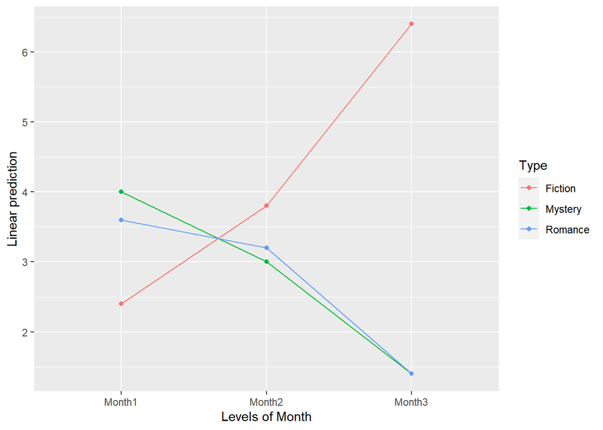

```r
#交互作用
m %>% emmip(Type~Month)
```

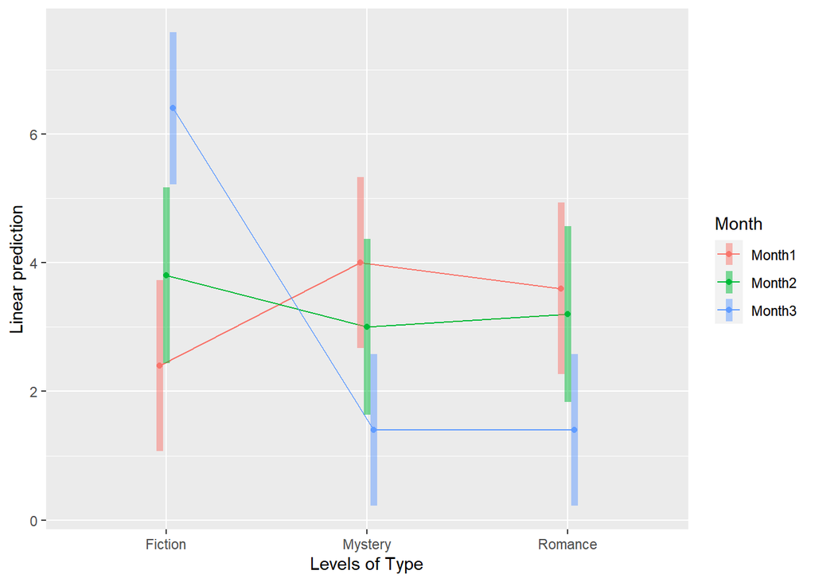

```r
m %>% emmip(Month~Type, CIs=T)
```